# ERGM_EGO_ELSOC

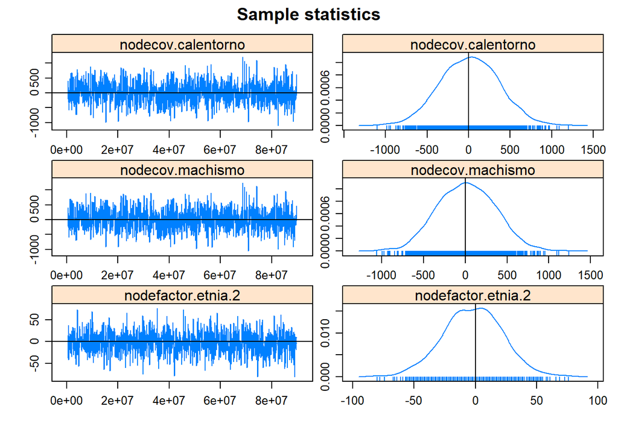

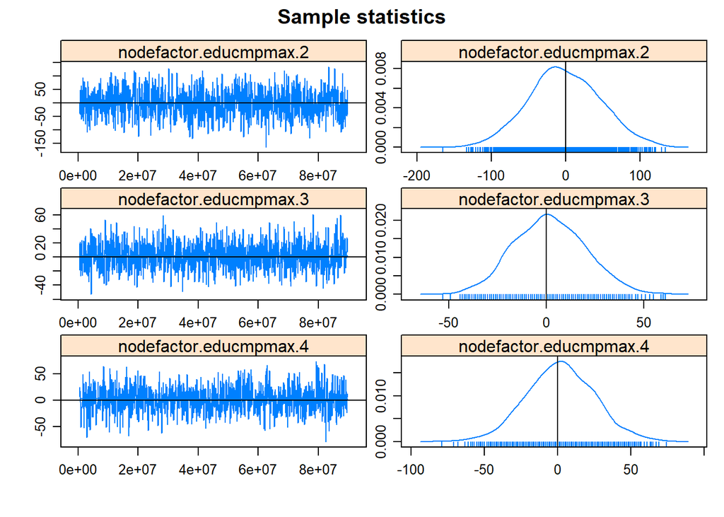

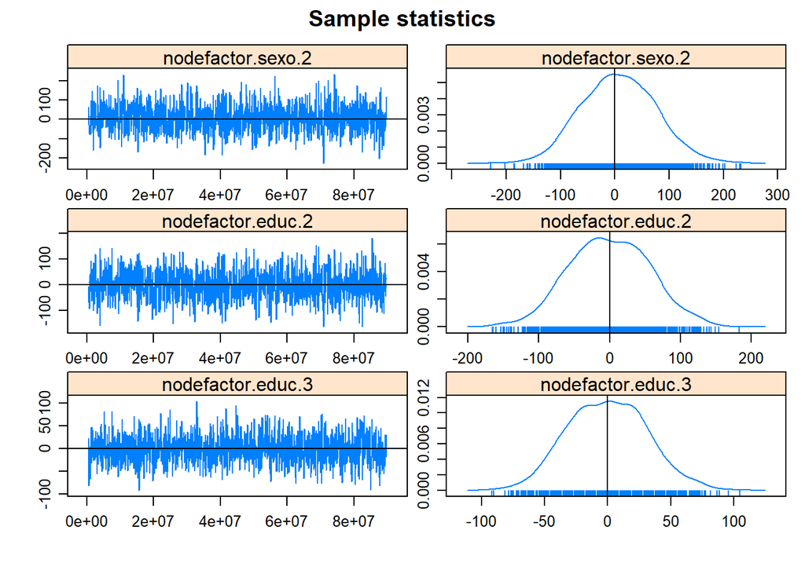

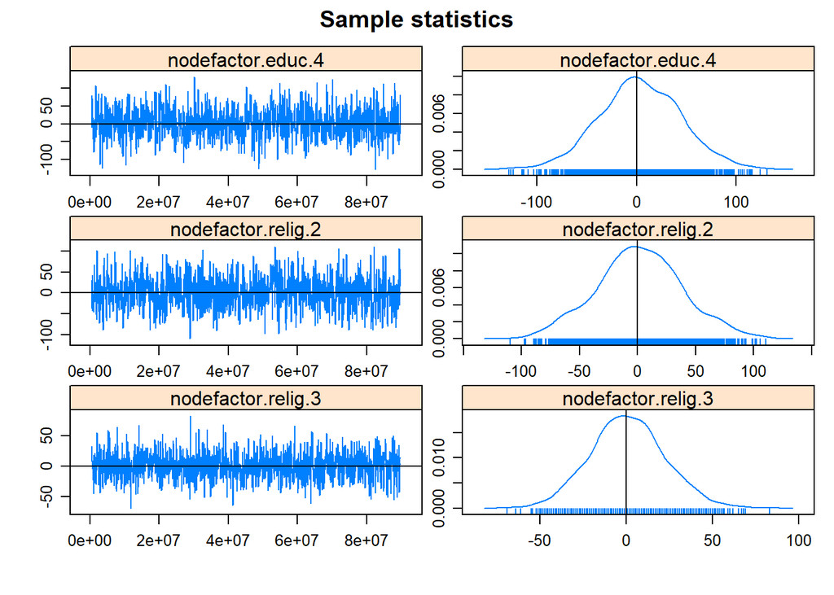

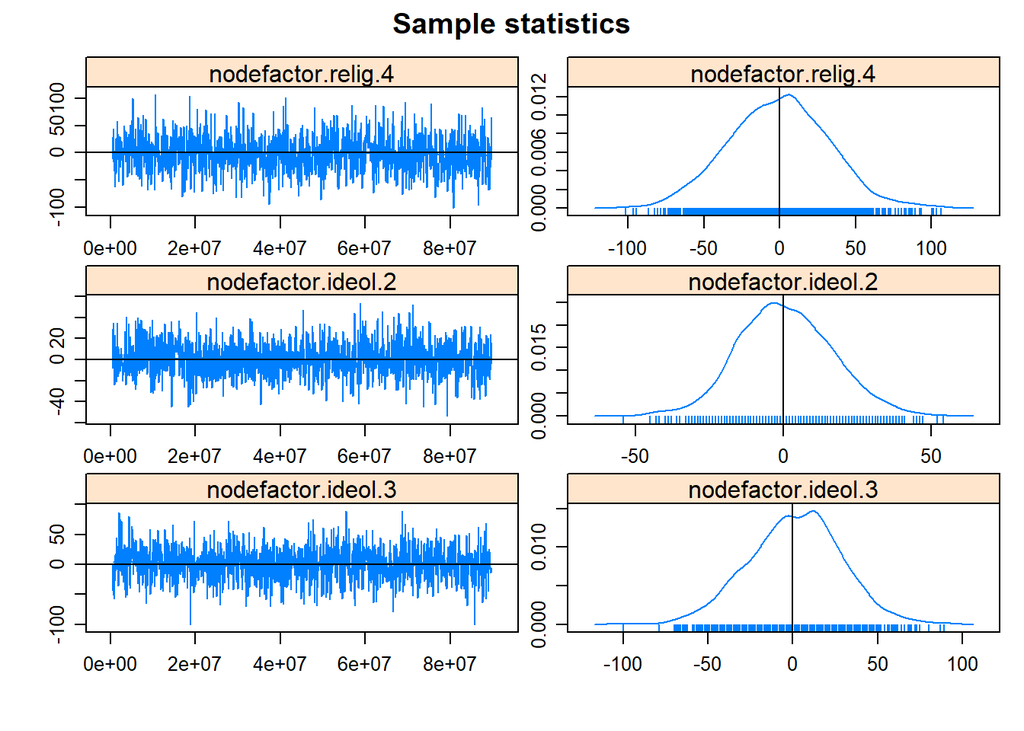

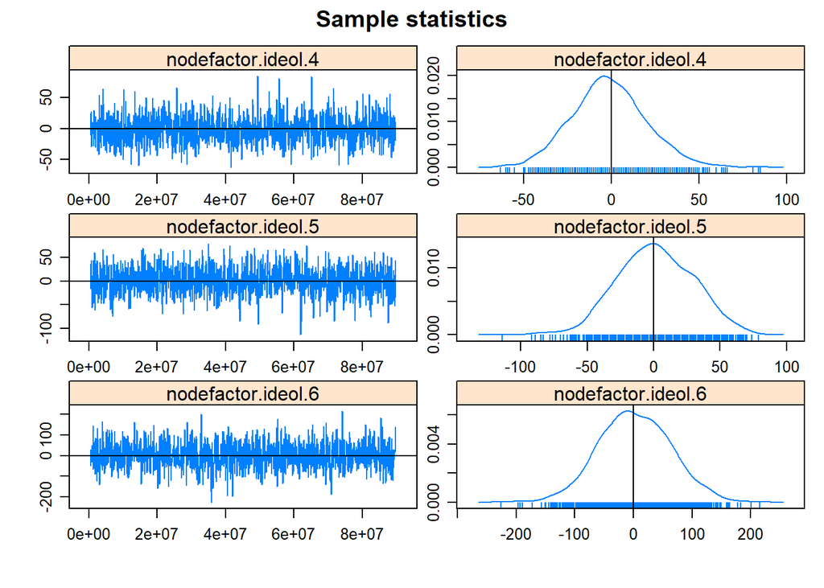

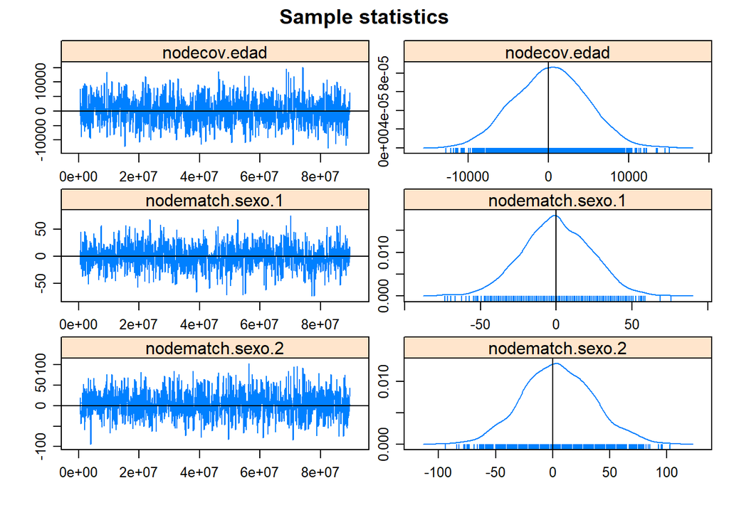

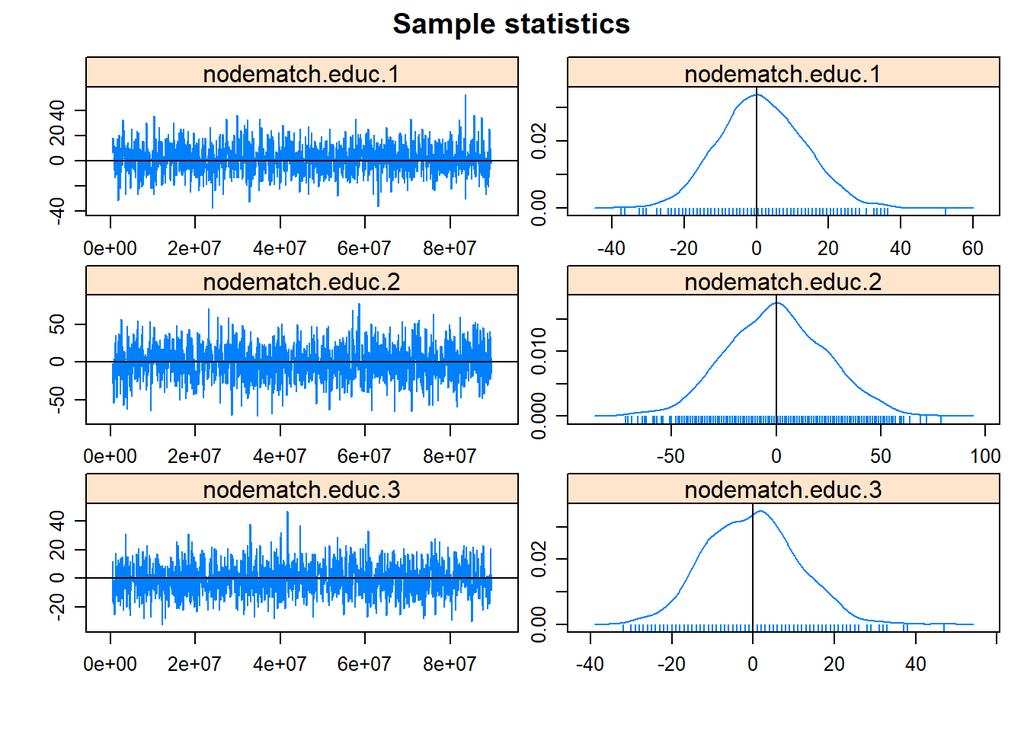

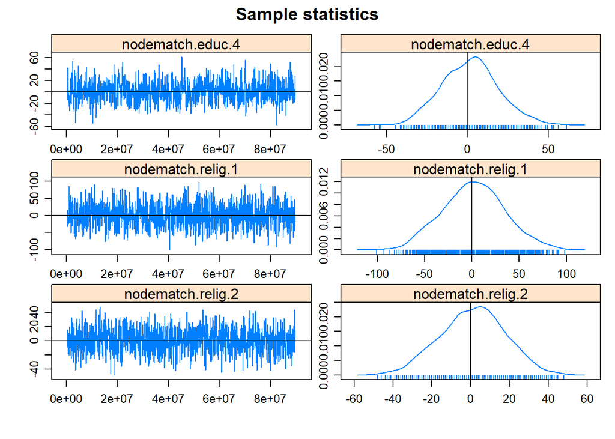

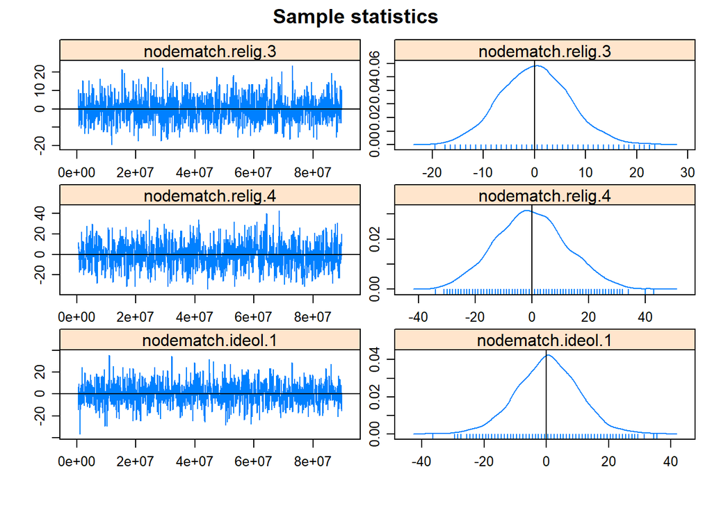

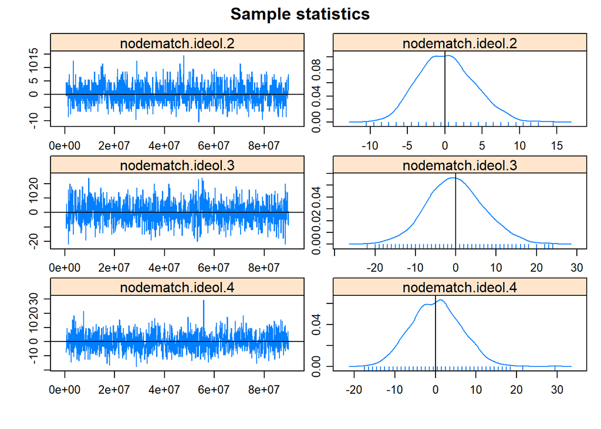

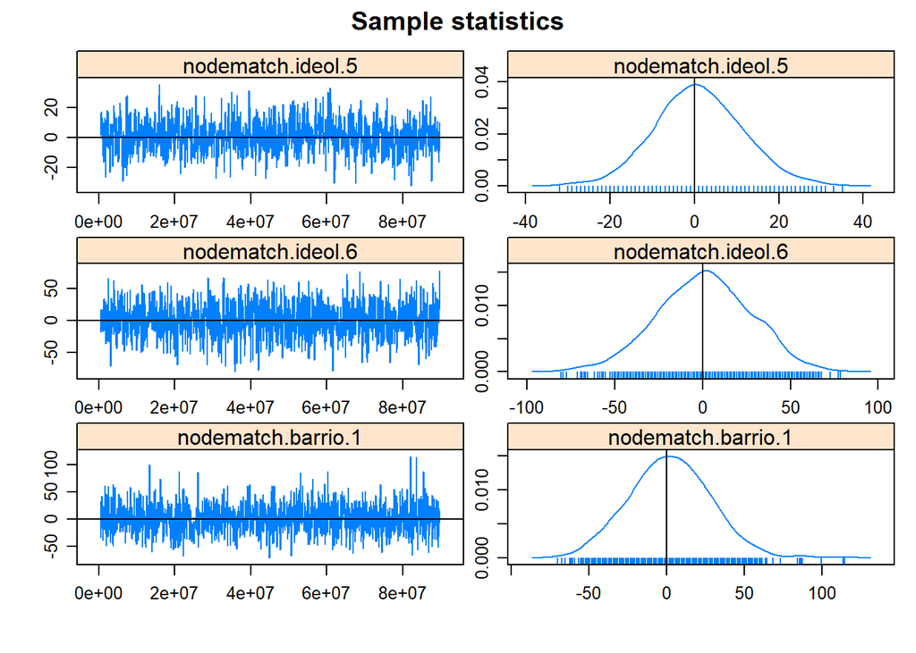

[1 more figures not shown]

[output not shown]

```r
mcmc.diagnostics(modelo10, which ="plots")
```

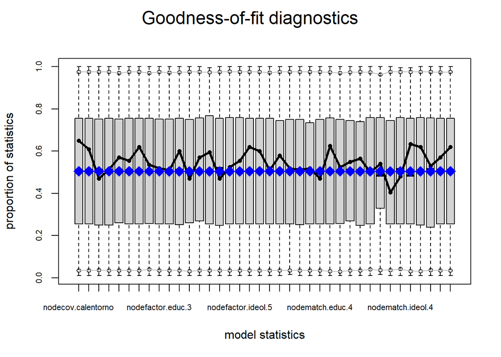

```r
plot(gof(modelo10, GOF="model"))
```

```r
elsoc_ego_nofam[["ego"]]  <-elsoc_ego_nofam[["ego"]]%>%drop_na(relig)
elsoc_ego_nofam[["alter"]]<-elsoc_ego_nofam[["alter"]]%>%drop_na(relig)
elsoc_ego_nofam[["ego"]]  <-elsoc_ego_nofam[["ego"]]%>%drop_na(sexo)
elsoc_ego_nofam[["alter"]]<-elsoc_ego_nofam[["alter"]]%>%drop_na(sexo)
elsoc_ego_nofam[["ego"]]  <-elsoc_ego_nofam[["ego"]]%>%drop_na(ideol)
elsoc_ego_nofam[["alter"]]<-elsoc_ego_nofam[["alter"]]%>%drop_na(ideol)
elsoc_ego_nofam[["ego"]]  <-elsoc_ego_nofam[["ego"]]%>%drop_na(educ)
elsoc_ego_nofam[["alter"]]<-elsoc_ego_nofam[["alter"]]%>%drop_na(educ)
elsoc_ego_nofam[["alter"]]<-elsoc_ego_nofam[["alter"]]%>%drop_na(barrio)
elsoc_ego_nofam[["ego"]]$calentorno<-as.numeric(elsoc_ego_nofam[["ego"]]$calentorno)
elsoc_ego_nofam[["ego"]]<-elsoc_ego_nofam[["ego"]]%>%drop_na(calentorno)
elsoc_ego_nofam[["ego"]]$machismo<-as.numeric(elsoc_ego_nofam[["ego"]]$machismo)
elsoc_ego_nofam[["ego"]]<-elsoc_ego_nofam[["ego"]]%>%drop_na(machismo)

#elsoc_ego[["ego"]]$educmpmax<-as.numeric(elsoc_ego[["ego"]]$educmpmax)
elsoc_ego_nofam[["ego"]]<-elsoc_ego_nofam[["ego"]]%>%drop_na(educmpmax)
elsoc_ego_nofam[["ego"]]<-elsoc_ego_nofam[["ego"]]%>%drop_na(etnia)
```

```r
modelo11<-ergm.ego(elsoc_ego_nofam~
                  + edges
                  + nodecov("machismo")
                  + nodecov("calentorno")
                  + nodefactor("etnia")
                  + nodefactor("educmpmax")
                  + nodefactor("sexo")
                  + nodefactor("educ")
                  + nodefactor("relig")
                  + nodefactor("ideol")
                  + nodecov("edad"),
                  control=control.ergm.ego(ppopsize="samp",
                                           ppop.wt="sample",
                                           stats.wt="data",
                                           stats.est="survey"),
                  ignore.max.alters=FALSE,
                  boot.R = 10000,
                  ergm = control.ergm(init.method = "MPLE",
                  init.MPLE.samplesize = 5e7,
                  MPLE.constraints.ignore = TRUE,
                  MCMLE.effectiveSize = NULL,
                  MCMC.burnin = 5e4,
                  MCMC.interval = 5e4,
                  MCMC.samplesize = 7500,
                  parallel = 16,
                  SAN.nsteps = 5e7))

summary(modelo11)
```

```
## Call:
## ergm(formula = ergm.formula, constraints = constraints, offset.coef = ergm.offset.coef,
##     target.stats = m, eval.loglik = FALSE, control = control$ergm,
##     ignore.max.alters = FALSE, boot.R = 10000, ergm = ..3)
##
## Monte Carlo Maximum Likelihood Results:
##
##                         Estimate Std. Error MCMC % z value Pr(>|z|)
## offset(netsize.adj)    -7.374629   0.000000      0    -Inf  < 1e-04 ***
## edges                  -0.723748   0.759136      0  -0.953 0.340395
## nodecov.machismo       -0.007569   0.063671      0  -0.119 0.905369
## nodecov.calentorno      0.240230   0.055431      0   4.334  < 1e-04 ***
## nodefactor.etnia.2     -0.045001   0.122405      0  -0.368 0.713143
## nodefactor.educmpmax.2 -0.090640   0.098019      0  -0.925 0.355115
## nodefactor.educmpmax.3  0.014737   0.172799      0   0.085 0.932037
## nodefactor.educmpmax.4 -0.170505   0.145713      0  -1.170 0.241943
## nodefactor.sexo.2      -0.205737   0.072071      0  -2.855 0.004309 **
## nodefactor.educ.2       0.283348   0.094026      0   3.014 0.002582 **
## nodefactor.educ.3       0.405450   0.129899      0   3.121 0.001801 **
## nodefactor.educ.4       0.807286   0.132316      0   6.101  < 1e-04 ***
## nodefactor.relig.2     -0.098931   0.087303      0  -1.133 0.257131
## nodefactor.relig.3     -0.448220   0.110486      0  -4.057  < 1e-04 ***
## nodefactor.relig.4      0.137725   0.080155      0   1.718 0.085754 .
## nodefactor.ideol.2     -0.625650   0.147704      0  -4.236  < 1e-04 ***
## nodefactor.ideol.3     -0.576310   0.111771      0  -5.156  < 1e-04 ***
## nodefactor.ideol.4     -0.440775   0.124093      0  -3.552 0.000382 ***
## nodefactor.ideol.5     -0.198851   0.120529      0  -1.650 0.098981 .
## nodefactor.ideol.6     -0.158825   0.098618      0  -1.611 0.107286
## nodecov.edad           -0.006919   0.002605      0  -2.656 0.007897 **
## ---
## Signif. codes:  0 '***' 0.001 '**' 0.01 '*' 0.05 '.' 0.1 ' ' 1
##
##
##  The following terms are fixed by offset and are not estimated:
##   offset(netsize.adj)
```

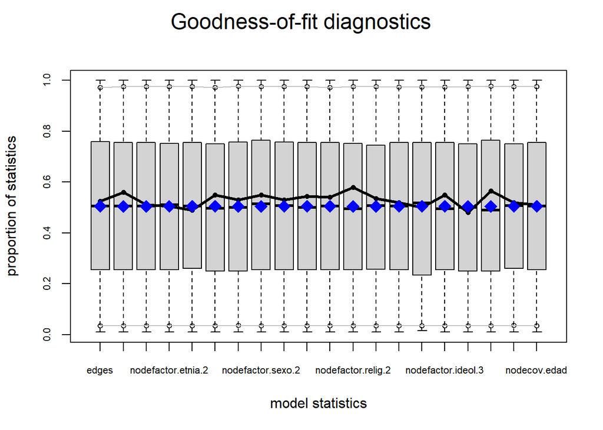

```r
plot(gof(modelo11, GOF="model"))
```

# 14 modelo 12 (alteris no fam homofilia diferencial)

```r
modelo12<-ergm.ego(elsoc_ego_nofam~edges
                  + nodematch("sexo",  diff=TRUE)
                  + nodematch("educ",  diff=TRUE)
                  + nodematch("relig", diff=TRUE)
                  + nodematch("ideol", diff=TRUE)
                  + nodematch("barrio", diff=TRUE)
                  + absdiff("edad"),
                  control=control.ergm.ego(ppopsize="samp",
                                           ppop.wt="sample",
                                           stats.wt="data",
                                           stats.est="survey"),
                  ignore.max.alters=FALSE,
                  boot.R = 10000,
                  ergm = control.ergm(init.method = "MPLE",
                  init.MPLE.samplesize = 5e7,
                  MPLE.constraints.ignore = TRUE,
                  MCMLE.effectiveSize = NULL,
                  MCMC.burnin = 5e4,
                  MCMC.interval = 5e4,
                  MCMC.samplesize = 7500,
                  parallel = 16,
                  SAN.nsteps = 5e7))

#?control.ergm.ego
summary(modelo12)
```

```
## Call:
## ergm(formula = ergm.formula, constraints = constraints, offset.coef = ergm.offset.coef,
##     target.stats = m, eval.loglik = FALSE, control = control$ergm,
##     ignore.max.alters = FALSE, boot.R = 10000, ergm = ..3)
##
## Monte Carlo Maximum Likelihood Results:
##
##                      Estimate Std. Error MCMC % z value Pr(>|z|)
## offset(netsize.adj) -7.374629   0.000000      0    -Inf  < 1e-04 ***
## edges               -0.670158   0.108033      0  -6.203  < 1e-04 ***
## nodematch.sexo.1     1.762427   0.098346      0  17.921  < 1e-04 ***
## nodematch.sexo.2     1.286206   0.086318      0  14.901  < 1e-04 ***
## nodematch.educ.1     0.605256   0.152627      0   3.966  < 1e-04 ***
## nodematch.educ.2     0.499805   0.085795      0   5.826  < 1e-04 ***
## nodematch.educ.3     1.251837   0.133146      0   9.402  < 1e-04 ***
## nodematch.educ.4     1.731544   0.093327      0  18.553  < 1e-04 ***
## nodematch.relig.1    0.536512   0.078220      0   6.859  < 1e-04 ***
## nodematch.relig.2    1.256361   0.121948      0  10.302  < 1e-04 ***
## nodematch.relig.3    0.873648   0.284837      0   3.067 0.002161 **
## nodematch.relig.4    1.153389   0.146528      0   7.871  < 1e-04 ***
## nodematch.ideol.1    1.559870   0.206218      0   7.564  < 1e-04 ***
## nodematch.ideol.2    0.811652   0.330634      0   2.455 0.014095 *
## nodematch.ideol.3   -0.365601   0.273871      0  -1.335 0.181896
## nodematch.ideol.4    0.087369   0.223879      0   0.390 0.696350
## nodematch.ideol.5    1.751155   0.163475      0  10.712  < 1e-04 ***
## nodematch.ideol.6    0.594702   0.090142      0   6.597  < 1e-04 ***
## nodematch.barrio.1  -0.661388   0.084560      0  -7.821  < 1e-04 ***
## nodematch.barrio.2   0.322847   0.091299      0   3.536 0.000406 ***
## absdiff.edad        -0.081197   0.004728      0 -17.173  < 1e-04 ***
## ---
## Signif. codes:  0 '***' 0.001 '**' 0.01 '*' 0.05 '.' 0.1 ' ' 1
##
##
##  The following terms are fixed by offset and are not estimated:
##   offset(netsize.adj)
```

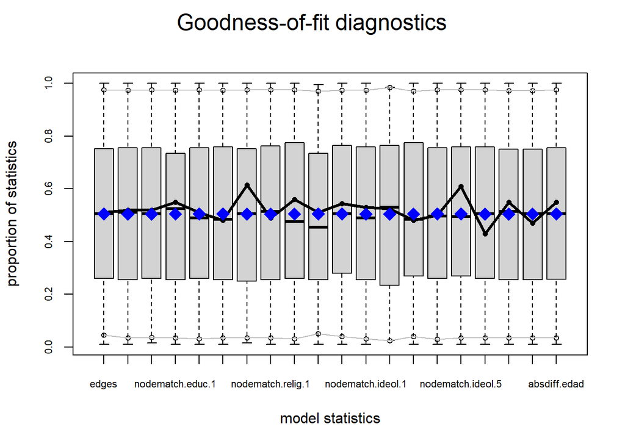

```r
plot(gof(modelo12, GOF="model"))
```

## 14.1 modelo 13 (alteris nofam, todos los parámetros)

```r
modelo13 <- ergm.ego(elsoc_ego_nofam ~
                  + nodecov("calentorno")
                  + nodecov("machismo")
                  + nodefactor("etnia")
                  + nodefactor("educmpmax")
                  + nodefactor("sexo")
                  + nodefactor("educ")
                  + nodefactor("relig")
                  + nodefactor("ideol")
                  + nodecov("edad")
                  + nodematch("sexo",  diff=TRUE)
                  + nodematch("educ",  diff=TRUE)
                  + nodematch("relig", diff=TRUE)
                  + nodematch("ideol", diff=TRUE)
                  + nodematch("barrio", diff=TRUE)
                  + absdiff("edad"),
                  control=control.ergm.ego(ppopsize="samp",
                                           ppop.wt="sample",
                                           stats.wt="data",
                                           stats.est="survey"),
                  ignore.max.alters=FALSE,
                  boot.R = 10000,
                  ergm = control.ergm(init.method = "MPLE",
                  init.MPLE.samplesize = 5e7,
                  MPLE.constraints.ignore = TRUE,
                  MCMLE.effectiveSize = NULL,
                  MCMC.burnin = 5e4,
                  MCMC.interval = 5e4,
                  MCMC.samplesize = 7500,
                  parallel = 16,
                  SAN.nsteps = 5e7))

summary(modelo13)
```

```
## Call:
## ergm(formula = ergm.formula, constraints = constraints, offset.coef = ergm.offset.coef,
##     target.stats = m, eval.loglik = FALSE, control = control$ergm,
##     ignore.max.alters = FALSE, boot.R = 10000, ergm = ..3)
##
## Monte Carlo Maximum Likelihood Results:
##
##                         Estimate Std. Error MCMC % z value Pr(>|z|)
## offset(netsize.adj)    -7.374629   0.000000      0    -Inf  < 1e-04 ***
## nodecov.calentorno      0.205336   0.052712      0   3.895  < 1e-04 ***
## nodecov.machismo       -0.034507   0.063072      0  -0.547  0.58431
## nodefactor.etnia.2      0.034762   0.127331      0   0.273  0.78485
## nodefactor.educmpmax.2 -0.098255   0.104742      0  -0.938  0.34821
## nodefactor.educmpmax.3 -0.143692   0.180314      0  -0.797  0.42551
## nodefactor.educmpmax.4 -0.161801   0.153291      0  -1.056  0.29119
## nodefactor.sexo.2      -2.566924   0.636826      0  -4.031  < 1e-04 ***
## nodefactor.educ.2       0.357641   0.109043      0   3.280  0.00104 **
## nodefactor.educ.3       0.459333   0.155494      0   2.954  0.00314 **
## nodefactor.educ.4       0.510589   0.159270      0   3.206  0.00135 **
## nodefactor.relig.2     -0.019607   0.146616      0  -0.134  0.89362
## nodefactor.relig.3     -0.045097   0.163977      0  -0.275  0.78330
## nodefactor.relig.4      0.288836   0.140624      0   2.054  0.03998 *
## nodefactor.ideol.2     -0.435249   0.150841      0  -2.885  0.00391 **
## nodefactor.ideol.3     -0.048572   0.136220      0  -0.357  0.72141
## nodefactor.ideol.4     -0.119679   0.147285      0  -0.813  0.41647
## nodefactor.ideol.5     -0.101854   0.126448      0  -0.806  0.42053
## nodefactor.ideol.6     -0.081544   0.123984      0  -0.658  0.51074
## nodecov.edad            0.001148   0.002689      0   0.427  0.66944
## nodematch.sexo.1       -0.706212   0.644879      0  -1.095  0.27347
## nodematch.sexo.2        3.778541   0.664244      0   5.688  < 1e-04 ***
## nodematch.educ.1        1.022702   0.178707      0   5.723  < 1e-04 ***
## nodematch.educ.2        0.335589   0.143688      0   2.336  0.01952 *
## nodematch.educ.3        1.087404   0.201009      0   5.410  < 1e-04 ***
## nodematch.educ.4        1.627378   0.171407      0   9.494  < 1e-04 ***
## nodematch.relig.1       0.800936   0.159800      0   5.012  < 1e-04 ***
## nodematch.relig.2       1.302901   0.194914      0   6.684  < 1e-04 ***
## nodematch.relig.3       0.453212   0.325552      0   1.392  0.16388
## nodematch.relig.4       0.961357   0.194179      0   4.951  < 1e-04 ***
## nodematch.ideol.1       1.042975   0.233398      0   4.469  < 1e-04 ***
## nodematch.ideol.2       0.630511   0.461982      0   1.365  0.17232
## nodematch.ideol.3      -0.270141   0.309937      0  -0.872  0.38343
## nodematch.ideol.4       0.563461   0.280173      0   2.011  0.04431 *
## nodematch.ideol.5       1.674063   0.218116      0   7.675  < 1e-04 ***
## nodematch.ideol.6       0.634014   0.147231      0   4.306  < 1e-04 ***
## nodematch.barrio.1     -0.540657   0.088310      0  -6.122  < 1e-04 ***
## nodematch.barrio.2      0.211409   0.089231      0   2.369  0.01783 *
## absdiff.edad           -0.080408   0.004280      0 -18.788  < 1e-04 ***
## ---
## Signif. codes:  0 '***' 0.001 '**' 0.01 '*' 0.05 '.' 0.1 ' ' 1
##
##
##  The following terms are fixed by offset and are not estimated:
##   offset(netsize.adj)
```

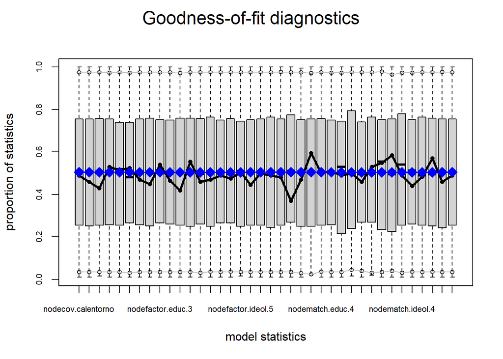

```r
plot(gof(modelo13, GOF="model"))
```

# 15 Extras

## 15.1 Sample para simulación

```r
s1 <- sample(elsoc_ego, 100, replace=TRUE, prob=1:nrow(elsoc_ego$ego))
```

## 15.2 Modelo para graficar

```r
#sim1 <- sample(elsoc_ego, 150, replace = TRUE)
#sim1
#s1[["ego"]]  <-s1[["ego"]]%>%drop_na(relig)
#s1[["alter"]]<-s1[["alter"]]%>%drop_na(relig)
#s1[["ego"]]  <-s1[["ego"]]%>%drop_na(sexo)
#s1[["alter"]]<-s1[["alter"]]%>%drop_na(sexo)
#s1[["ego"]]  <-s1[["ego"]]%>%drop_na(ideol)
#s1[["alter"]]<-s1[["alter"]]%>%drop_na(ideol)
#s1[["ego"]]  <-s1[["ego"]]%>%drop_na(educ)
#s1[["alter"]]<-s1[["alter"]]%>%drop_na(educ)
#s1[["alter"]]<-s1[["alter"]]%>%drop_na(barrio)
#s1[["ego"]]$calentorno<-as.numeric(sim1[["ego"]]$calentorno)
#s1[["ego"]]<-sim1[["ego"]]%>%drop_na(calentorno)
#s1[["ego"]]$machismo<-as.numeric(sim1[["ego"]]$machismo)
#s1[["ego"]]<-sim1[["ego"]]%>%drop_na(machismo)
#elsoc_ego[["ego"]]$educmpmax<-as.numeric(elsoc_ego[["ego"]]$educmpmax)
#sim1[["ego"]]<-sim1[["ego"]]%>%drop_na(educmpmax)
#sim1[["ego"]]<-sim1[["ego"]]%>%drop_na(etnia)

modelo14 <- ergm.ego(s1 ~
                    nodefactor("educ")
                  + nodefactor("ideol")
                  + nodematch("educ")
                  + nodematch("ideol"),
                  ignore.max.alters=FALSE,
                  boot.R = 10000,
                  ergm = control.ergm(init.method = "MPLE",
                  init.MPLE.samplesize = 5e7,
                  MPLE.constraints.ignore = TRUE,
                  MCMLE.effectiveSize = NULL,
                  MCMC.burnin = 5e4,
                  MCMC.interval = 5e4,
                  MCMC.samplesize = 7500,
                  parallel = 16,
                  SAN.nsteps = 5e7))
sim.modelo14 <- simulate(modelo14)
summary(sim.modelo14)
```

```
## Network attributes:
##   vertices = 122
##   directed = FALSE
##   hyper = FALSE
##   loops = FALSE
##   multiple = FALSE
##   bipartite = FALSE
##  total edges = 198
##    missing edges = 0
##    non-missing edges = 198
##  density = 0.02682563
##
## Vertex attributes:
##
##  .ego.ind:
```

[output cut: 278 more lines]

## 15.3 Educación

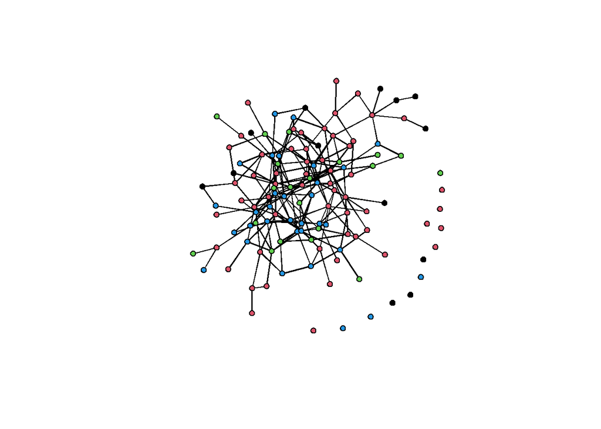

```r
p<-plot(sim.modelo14, vertex.col="educ")
```

```r
#p + legend('bottomleft',fill=1:4,legend=paste('educ',1:4),cex=0.75)
```

## 15.4 Ideología

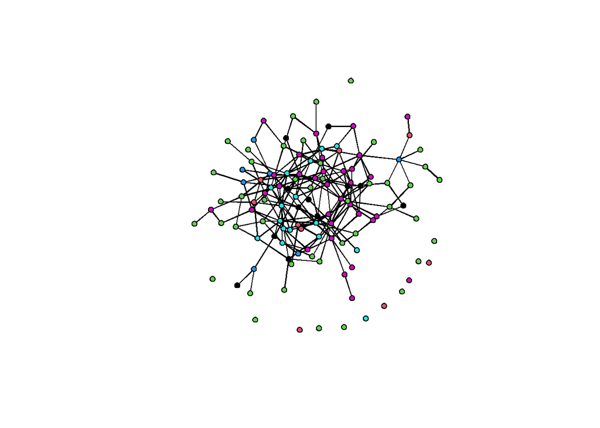

```r
p<-plot(sim.modelo14, vertex.col="ideol")
```

```r
#p + legend('bottomleft',fill=1:6,legend=paste('ideol',1:6),cex=0.75)
```

## 15.5 Religión

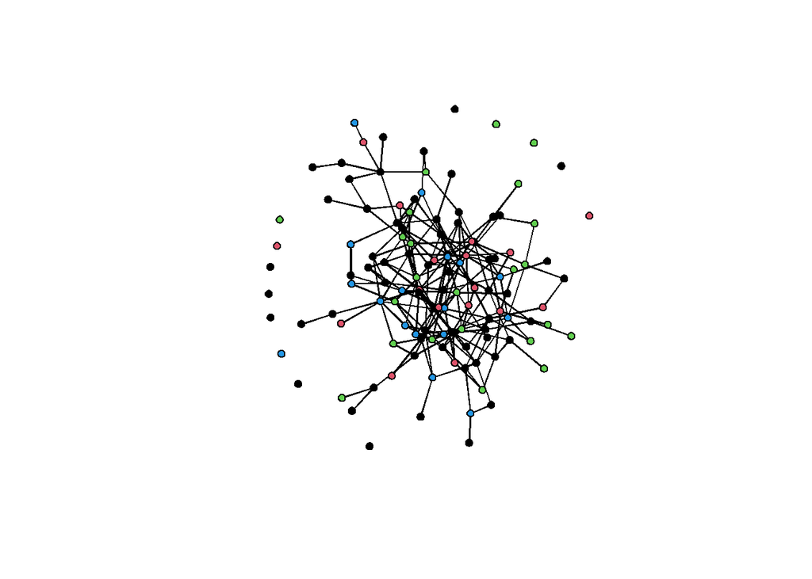

```r
p<-plot(sim.modelo14, vertex.col="relig")
```

```r
#p + legend('bottomleft',fill=1:4,legend=paste('relig',1:4),cex=0.75)
```

# 16 Análisis ELSOC 2019

## 16.1 Crear data frame alteris para 2019=b

```r
load("C:/Users/rober/Downloads/ELSOC_W04_v2.01_R.RData")
```

### 16.1.1 extraer var educ madre y padre

```r
elsoc_2016<-elsoc_2016%>%
  dplyr::select(idencuesta,m27,m28)
elsoc_2019<-left_join(elsoc_2019,elsoc_2016,by="idencuesta")
```

```r
b<-elsoc_2019 %>% dplyr::rename(.egoID = idencuesta)
```

Creamos subset con data de cada uno de los alteris mencionados, manteniendo el ID de cada ego en el cual están anidados. Las columnas de cada uno de los subset deben tener los mismos nombres.

```r
alter_1<-b %>%
        dplyr::select(.egoID,
                      sexo=r13_sexo_01,
                      edad=r13_edad_01,
                      educ=r13_educ_01,
                      relig=r13_relig_01,
                      ideol=r13_ideol_01,
                      barrio=r13_barrio_01,
                      rel=r13_relacion_01)
#View(alter_1)
alter_2<-b %>%
        dplyr::select(.egoID,
                      sexo=r13_sexo_02,
                      edad=r13_edad_02,
                      educ=r13_educ_02,
                      relig=r13_relig_02,
                      ideol=r13_ideol_02,
                      barrio=r13_barrio_02,
                      rel=r13_relacion_02)

alter_3<-b %>%
        dplyr::select(.egoID,
                      sexo=r13_sexo_03,
                      edad=r13_edad_03,
                      educ=r13_educ_03,
                      relig=r13_relig_03,
                      ideol=r13_ideol_03,
                      barrio=r13_barrio_03,
                      rel=r13_relacion_03)

alter_4<- b %>%
        dplyr::select(.egoID,
                      sexo=r13_sexo_04,
                      edad=r13_edad_04,
                      educ=r13_educ_04,
                      relig=r13_relig_04,
                      ideol=r13_ideol_04,
                      barrio=r13_barrio_04,
                      rel=r13_relacion_04)

alter_5<-b %>%
        dplyr::select(.egoID,
                      sexo=r13_sexo_05,
                      edad=r13_edad_05,
                      educ=r13_educ_05,
                      relig=r13_relig_05,
                      ideol=r13_ideol_05,
                      barrio=r13_barrio_05,
                      rel=r13_relacion_05)
```

## 16.2 setear

Creamos un vector adicional en cada subset de alteris con un número constante que identifica a que alter representa la data.

```r
alter_1$n<-1
alter_2$n<-2
alter_3$n<-3
alter_4$n<-4
alter_5$n<-5
```

## 16.3 Crear base de alteris en formato *long*

```r
alteris<-rbind(alter_1,alter_2,alter_3,alter_4,alter_5)
alteris<-arrange(alteris, .egoID)
```

## 16.4 Crear vector alter id

En el siguiente chunk creamos un vector identificador para cada uno de los alteris presentes en la data “alteris”. Lo identificamos como objeto `tibble` y eliminamos el vector “n”.

```r
alteris   <- rowid_to_column(alteris, var = ".alterID")
alteris   <- as_tibble(alteris)
alteris$n <- NULL
```

## 16.5 Recod alteris

Recodificamos los valores de los atributos de los alteris.

```r
# NA
alteris[alteris=="-999"]<-NA
alteris[alteris=="-888"]<-NA

# Educación
#edulab<-c('ltsecondary', 'secondary', 'technicaled', 'collegeed')
alteris$educ <-factor(Recode(alteris$educ ,"1=1;2:3=2;4=3;5=4"))
table(alteris$educ)
```

```
##
##    1    2    3    4
## 1098 3467 1095 2070
```

```r
# Religión
#relilab<-c('catholic','evangelical','other','none')
alteris$relig<-factor(Recode(alteris$relig,"1=1;2=2;3:4=4;5=3"))
table(alteris$relig)
```

```
##
##    1    2    3    4
## 4710 1371  327 1389
```

```r
# Ideología
#ideolab<-c('rightwinger','centerright','center','centerleft','leftwinger','none')
alteris$ideol<-factor(Recode(alteris$ideol,"1=1;2=2;3=3;4=4;5=5;6=6"))
table(alteris$ideol)
```

```
##
##    1    2    3    4    5    6
##  745  342  521  524 1062 4073
```

```r
# Edad
alteris$edad<-as.numeric(alteris$edad)
#alteris$edad <-factor(Recode(alteris$edad ,"0:18=1;19:29=2;30:40=3;41:51=4;52:62=5;63:100=6"))

# Sexo
#sexolab<-c('male','female')
alteris$sexo <-factor(Recode(alteris$sexo ,"1=1;2=2"))
table(alteris$sexo)
```

```
##
##    1    2
## 3191 4971
```

```r
# Relación
alteris<-alteris%>%
  dplyr::mutate(rel=case_when(rel%in%1:3~"fam",
                              rel%in%4:5~"nofam"))
freq(table(alteris$rel))
```

```
##          n    % val%
## fam   4607 56.4 56.4
## nofam 3555 43.6 43.6
```

```r
# Barrio
alteris$barrio<-factor(Recode(alteris$barrio,"1=1;2=2"))
table(alteris$barrio)
```

```
##
##    1    2
## 2508 2656
```

```r
#alteris<-na.omit(alteris)
```

### 16.5.1 Borrar alteris con 5 parámetros con NA

```r
# Función para borrar casos con un número determinado de NA's.
#delete.na <- function(DF, n=0) {
#  DF[rowSums(is.na(DF)) <= n,]
#}
#
#alteris<-delete.na(alteris, 4) #borro los casos que tienen más de 4 NA.
```

## 16.6 Data Frame Ego’s

Creamos un subset con la data de ego equivalente a la data de los alteris. Las nombramos de la misma manera.

```r
egos <-b %>%
       dplyr::select(.egoID,
                     sexo=m0_sexo,
                     edad=m0_edad,
                     educ=m01,
                     relig=m38,
                     ideol=c15,
                     educp=m27,
                     educm=m28,
                     etnia=m53,
                     w=ponderador01,
                     t06_01,
                     t06_02,
                     t06_03,
                     t06_04,
                     t06_05,
                     t06_06,
                     t06_07,
                     t06_08,
                     g01_01,
                     g01_02,
                     g01_03,
                     g01_04,
                     g01_05,
                     g02_05)

egos <- as_tibble(egos)
```